# for_ifelse_solved

## What happens when we fit the wrong model to the data?

It is common in Statistics to wonder the impact of fitting the wrong model to the data.

For this exercise, we will focus on fitting unimodal distributions to multi-modal data.

### Problem 0, simulating multi-modal data via a Gaussian Mixture

You can imagine a distribution with $k$ modes comes from overlaying $k$ different Gaussian distributions on top of each other. To simulate something like that, we could define:

$$X \sim MultiNomial(p_1, p_2, \dots, p_k)$$$$Y|X \sim Normal(\mu_{X}, \sigma^2_{X})$$

where $p_i = P(X=i)$, then we say $Y$ is a mixture Gaussian with $k$ mixtures. There will be $3k$ number of parameters overall, $p_1, \dots, p_k$, $\mu_1, \dots, \mu_k$, and $\sigma^2_1, \dots, \sigma^2_k$.

The 2 stage expression above suggests how we could simulate this using standard distributions like the multinomial and Gaussian.

- Before you start coding, write down in words, how you would translate the mathematical expression into a 2 stage sampling process using the multinomial and Gaussian distribution. Make sure you reference the parameters in your description.

Solution:

- First, draw a multinomial distribution according to $p_1, \dots, p_k$, call the output $X$
- If $X = i$, draw a Gaussian random variable from $Normal(\mu_i, \sigma^2_i)$.

### Problem 1:

We will eventually write a function called `rmixgauss(n, mix_probs, mus, sds)` that draws $n$ different samples from a Mixture Gaussian.

However, we will start off with a simpler version called `binary_rmixgauss(n, mix_probs, mus, sds)` and slowly generalize this. As the name suggests, we will be assuming there are only 2 mixtures, i.e. $k = 2$.

Your function should use 2 built-in functions in R, `sample()` and `rnorm()` to help produce the final function. In particular, `sample()` has an argument `prob` that can adjust the sampling probabilities.

- What data type should each input be and their respective size?
- Write `binary_rmixgauss()` in 3 different ways:
  - Write a function called `bi_rmixgauss_single(mix_probs, mus, sds)` then use a for-loop to generate `n` samples.
  - Use `ifelse()` where the condition depends on the length `n` dice roll vector.
  - Use `for() {...}` and `if(){...}else{...}` to write your function.
- Comment and compare on the 3 functions above, e.g. which is easiest to read?

SOLUTION

- `n` should be an integer with length 1
- `mix_probs`, `mus`, and `sds` should all have length `2` and all be numeric vectors
- (optional) `mix_probs` and `sds` should be non-negative. (Note, `prob` in `sample()` will automatically normalize to 1).

```r
bi_rmixgauss_single <- function(mix_probs, mus, sds) {
        x <- sample(c(1, 2), 1, prob=mix_probs)
        return(rnorm(1, mus[x], sds[x]))
    }

binary_rmixgauss1 <- function(n, mix_probs, mus, sds) {
    values <- vector('numeric', n)
    for(i in seq_len(n)){
        values[i] <- bi_rmixgauss_single(mix_probs, mus, sds)
    }
    return(values)
}
```

```r
binary_rmixgauss2 <- function(n, mix_probs, mus, sds) {
    rolls <- sample(c(TRUE, FALSE), n, replace=TRUE, prob=mix_probs)
    values <- ifelse(rolls,
                     rnorm(n, mus[1], sds[1]),
                     rnorm(n, mus[2], sds[2]))
    return(values)
}
```

```r
binary_rmixgauss3 <- function(n, mix_probs, mus, sds) {
    rolls <- sample(c(TRUE, FALSE), n, replace=TRUE, prob=mix_probs)
    values <- vector('numeric', n)
    for(i in seq_along(rolls)){
        if(rolls[i]) {
            out <- rnorm(1, mus[1], sds[1])
        } else {
            out <- rnorm(1, mus[2], sds[2])
        }
        values[i] <- out
    }
    return(values)
}
```

- The first function separates the single sample vs replication logic but can be inefficient because it's calling the high-level functions multiple times. It's also relatively verbose.
- The second one is clean but heavily relies on the fact that k=2. (It also creates both vectors in the back which is more taxing from a memory perspective).
- The third one depends on how they coded it up, but it also allows them to do elif() if they're willing to write it down. It's verbose and a bit hard to read.

### Problem 2: Testing your functions

Please run the following test cases against your favorite version from Problem 1.

- Test cases:
  - `binary_rmixgauss(-1, c(0.5, 0.5), c(0, 10), c(3, 3))`
  - `binary_rmixgauss(0, c(0.5, 0.5), c(0, 10), c(3, 3))`
  - `binary_rmixgauss(10, c(1, 0), c(0, 10), c(3, 3))`
  - `binary_rmixgauss(10, c(0.33, 0.67, 0.5), c(0, 10), c(3, 3))`
  - `binary_rmixgauss(10, c(0.33, 0.33), c(0, 10, -10), c(3, 3))`
  - `binary_rmixgauss(10, c(0.33, 0.33), c(0, 10), c(3, 3, -1))`
  - `binary_rmixgauss(10, c(0.33, 0.67), c(0, 10), c(3, -1))`
  - `binary_rmixgauss(c(10, 5), c(0.33, 0.33), c(0, 10), c(3, 1))`
  - `binary_rmixgauss(10, c(0.5, 0.5), c(0, 10), c(1, 1))`
- Make sure each test case is performing as you expected, discuss with your group to make sure you're on the same page.
  - Notice how R handles all the different cases!
- Try running all 3 versions of your function on the last test case but increase `n=100`, and look at the data using `hist(data)` hint:

  ```
  funs <- c(median, mean, sum)
  data <- c(1, 1, 1, 1, 1, 100)
  for(my_fun in funs){
      print(my_fun(data))
  }
  ```

- What is the data type for `funs` in the example above?

SOLUTION

```r
# Should produce an error
binary_rmixgauss1(-1, c(0.5, 0.5), c(0, 10), c(3, 3))
```

```
Error in vector("numeric", n): invalid 'length' argument
Traceback:

1. binary_rmixgauss1(-1, c(0.5, 0.5), c(0, 10), c(3, 3))
```

```r
# Should return NOTHING
binary_rmixgauss1(0, c(0.5, 0.5), c(0, 10), c(3, 3))
```

```r
# Should return only values from mean 0 case
binary_rmixgauss1(10, c(1, 0), c(0, 10), c(3, 3))
```

1. 3.02497985268549

2. -2.52731873502818

3. -2.60447076069785

4. 4.12542684366604

5. 0.657855335209993

6. 1.2948763525712

7. 0.291659455235568

8. 1.99137781155041

9. -1.41501932084509

10. 2.461258764817

```r
# Should return error
binary_rmixgauss1(10, c(0.33, 0.67, 0.5), c(0, 10), c(3, 3))
```

```
Error in sample.int(length(x), size, replace, prob): incorrect number of probabilities
Traceback:

1. binary_rmixgauss1(10, c(0.33, 0.67, 0.5), c(0, 10), c(3, 3))
2. bi_rmixgauss_single(mix_probs, mus, sds)   # at line 9 of file <text>
3. sample(c(1, 2), 1, prob = mix_probs)   # at line 2 of file <text>
4. sample.int(length(x), size, replace, prob)
```

```r
# Should ignore the last mus, if not sure, shrink the SDs
binary_rmixgauss1(10, c(0.33, 0.33), c(0, 10, -10), c(3, 3))
```

1. -0.990536777290922

2. 0.84798307990531

3. 3.31997209794465

4. 1.8030104907173

5. 4.64741507323472

6. 6.21935646591135

7. 9.7013651834293

8. -0.545779192317577

9. -3.55833148639729

10. -2.75266935673357

```r
# Should ignore the last SDs, hopefully they'll try to
# flip the parameters around, should produce NAs
binary_rmixgauss1(10, c(0.33, 0.33), c(0, 10), c(3, 3, -1))
```

1. 13.1750570226205

2. 3.76326703667496

3. -0.372756739827042

4. 5.67714343390914

5. 6.72132021984264

6. 13.4760124780858

7. 8.38757715413823

8. 9.40890916264648

9. 10.0974654283791

10. 3.91067856674264

```r
# Should produce NAs
binary_rmixgauss1(10, c(0.33, 0.67), c(0, 10), c(3, -1))
```

1. 0.379769553065224

2. -0.582922271763398

3. -0.945352808302461

4. 1.63629269328908

5. NaN

6. NaN

7. 2.5544920704299

8. NaN

9. -1.37076841575388

10. -3.52764469114222

```r
binary_rmixgauss1(c(10, 5), c(0.33, 0.33), c(0, 10), c(3, 1))
```

```
Error in vector("numeric", n): invalid 'length' argument
Traceback:

1. binary_rmixgauss1(c(10, 5), c(0.33, 0.33), c(0, 10), c(3, 1))
```

```r
# should run fine :)
binary_rmixgauss1(10, c(0.5, 0.5), c(0, 10), c(1, 1))
```

1. -0.352624755920777

2. 1.52481954370315

3. 1.63145611150923

4. -1.2026304066328

5. 9.83758489248793

6. 10.2026683477837

7. -0.150843579989744

8. 0.566309626509561

9. 0.302653017031222

10. 8.83386837466575

```r
binary_rmixgausss <- c(binary_rmixgauss1,
                       binary_rmixgauss2,
                       binary_rmixgauss3)
```

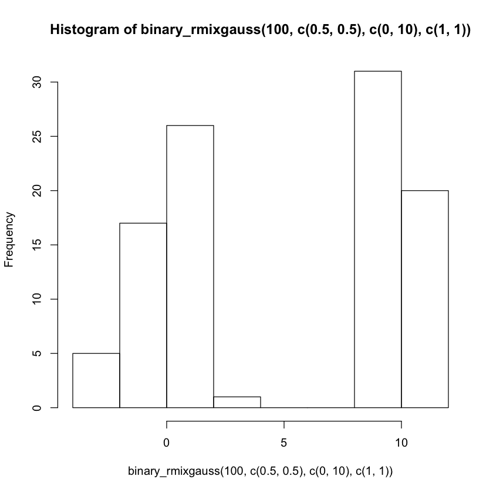

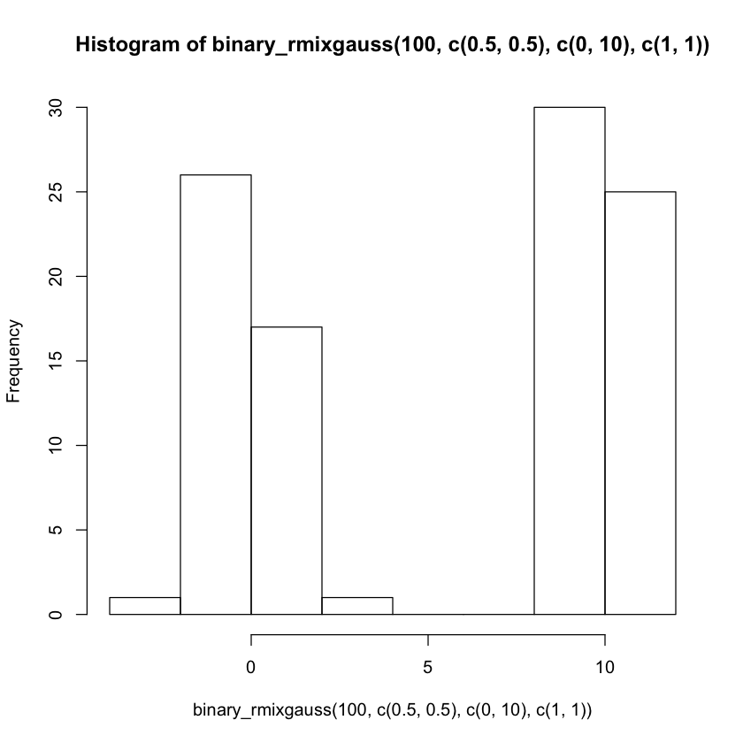

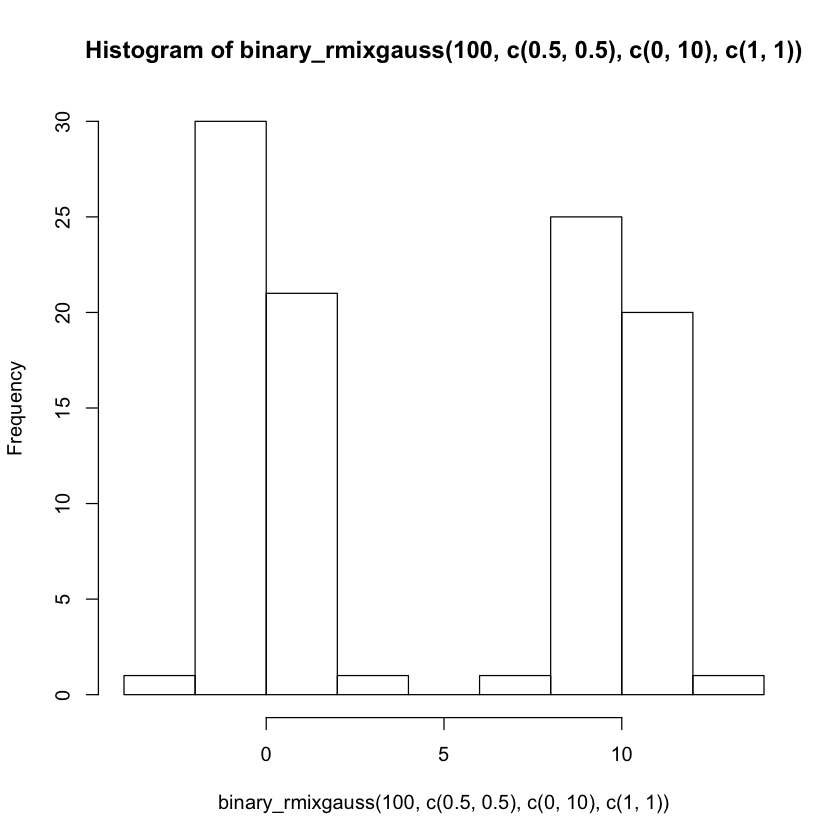

```r
for(i in seq_along(binary_rmixgausss)) {
    hist(binary_rmixgauss(100, c(0.5, 0.5), c(0, 10), c(1, 1)))
}
```

### Problem 3: Input validation

- In problem 1, we stated some expectations for the input lengths and data types. It's often good to check the inputs before executing any code. Please write a function called `check_rmixgauss_input()` that checks for the conditions you stated in Problem 1 and use `stop()` to give the user meaningful error messages.
- Please add this sanity check function into your favorite version of the `binary_rmixgauss()` function and run through **some of the** test cases one more time.

```r
# They don't have to catch EVERYTHING, but just have an idea of how to do this
check_rmixgauss_input <- function(n, mix_probs, mus, sds) {
    if(n < 0) {
        stop("n cannot be negative")
    }
    if(length(n) != 1) {
        stop("n should be length 1")
    }
    k <- length(mix_probs)
    if(length(sds) != k){
        stop("length of sds does not match mix_probs")
    }
    if(length(mus) != k){
        stop("length of mus does not match mix_probs")
    }
    inputs <- list(n, mix_probs, mus, sds)
    values <- vector('logical', length(inputs))
    for(input in inputs){
        if(class(input) != 'numeric') stop("all inputs must be numeric")
    }
}
```

```r
# Just add the function call within the original function
binary_rmixgauss2 <- function(n, mix_probs, mus, sds) {
    check_rmixgauss_input(n, mix_probs, mus, sds)
    rolls <- sample(c(TRUE, FALSE), n, replace=TRUE, prob=mix_probs)
    values <- ifelse(rolls,
                     rnorm(n, mus[1], sds[1]),
                     rnorm(n, mus[2], sds[2]))
    return(values)
}
```

```r
binary_rmixgauss2(10, c(0.33, 0.33), c(0, 10, -10), c(3, 3))
```

```
Error in check_rmixgauss_input(n, mix_probs, mus, sds): length of mus does not match mix_probs
Traceback:

1. binary_rmixgauss2(10, c(0.33, 0.33), c(0, 10, -10), c(3, 3))
2. check_rmixgauss_input(n, mix_probs, mus, sds)   # at line 3 of file <text>
3. stop("length of mus does not match mix_probs")   # at line 14 of file <text>
```

```r
binary_rmixgauss2(10, c(0.33, 0.33), c(0, 10), c(3, 3))
```

1. 7.31399812654538

2. 12.1674161556679

3. 13.7142032391554

4. 11.5632187339357

5. -3.90125781948919

6. 5.4700989505409

7. 10.4012780841477

8. 12.026756101964

9. 6.34543623972294

10. 2.27870975725953

### Problm 4: Simulating data and fitting the wrong model!

A method to fit a model to data is to **search** for the parameters that maximize the log-likelihood of observing the sample, i.e. $$\theta_{MLE} = \arg\max_{\theta} \log p_{\theta}(data)$$ So if we assume the data follows a Normal distribution and the samples are independent from one another, we can rewrite this as: $$\theta_{MLE} = \arg\max \log \prod_i \frac{1}{\sigma\sqrt{2\pi}} \exp\left(-\frac{1}{2} (\frac{y_i - \mu}{\sigma})^2\right)$$

- Please generate an **obviously bimodal** distribution using 1000 samples using your function above. Hint: you can check with `hist(rnorm(100))` to get the histogram of your samples.
- Since we have not covered optimization yet and to further illustrate the use of for-loops, we use a for-loop to sweep across a range of values to search for a reasonably parameters that can describe the data. Use `seq()` to create "reasonable" candidate values for both $\hat{\mu}$ and $\hat{\sigma}^2$ (you should have 2 vectors at the end of this, they do not need to be the same length).
- Pick arbitrary values among your candidate values from above, calculate the log-density of your sample using R's built-in function `dnorm(y, mu, sd, log=TRUE)`.
- Pick another set of arbitrary values among your candidate values from above, calculate the log-density, which set of parameter values is better? Why?
- Now calculate the log-density of your sample using **each possible combinations** of your candidate $\hat{\mu}$ and $\hat{\sigma}^2$ and report the pair that has the highest value. While comparing different combination of your candidate values, **if** the new pair of parameter values produce a larger log-density, **then** you should update your $\hat{\mu}$, and $\hat{\sigma}^2$. Hint:

  ```
  par1 <- 1:2
  par2 <- 4:7
  candidates <- expand.grid(par1, par2)
  dim(candidates)
  head(candidates)
  largest <- 0
  for(i in seq_len(dim(candidates)[1])){
      challenger <- candidates[i, 1] + candidates[i, 2]
      if(largest < challenger){

      }
  }
  ```

- Please plot your sample against your fitted Normal distribution by modifying the code below:

  ```
  data <- rnorm(1000)
  hist(data, freq = FALSE)
  best_normal <- function(x) return(dnorm(x, 0, 1))
  curve(best_normal, min(data), max(data), col="blue", add=TRUE)
  ```

- Please comment on whether the best model worked as you expected.

SOLUTION

```r
my_data <- binary_rmixgauss2(1000, c(0.2, 0.8), c(0, 10), c(1, 1))
```

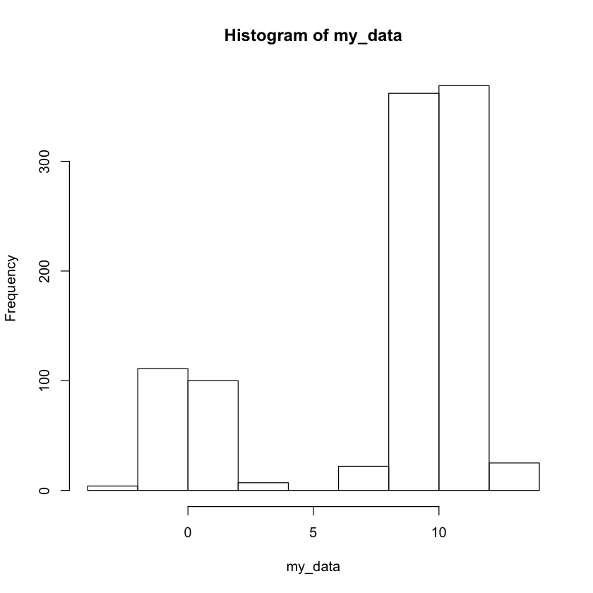

```r
hist(my_data)
```

```r
mu_cands <- seq(min(my_data), max(my_data), length.out = 1000)
# Go from the smallest SD of one of the mixtures to the whole range
# of the data
sd_cands <- seq(1, diff(range(my_data)), length.out = 1000)
```

```r
sum(dnorm(my_data, mu_cands[1], sd_cands[1], log=TRUE))
```

-69435.7081033775

```r
sum(dnorm(my_data, mu_cands[2], sd_cands[2], log=TRUE))
```

-67134.8564166493

```r
# The second one is larger so we like it more! By logic of of maximum likelihood.
```

```r
candidates <- expand.grid(mu_cands, sd_cands)
loglik <- sum(dnorm(my_data, mu_cands[1], sd_cands[1], log=TRUE))
best_para <- candidates[1, ]
for(i in seq_len(nrow(candidates))){
    next_loglik <- sum(dnorm(my_data,
                             candidates[i, 1],
                             candidates[i, 2],
                             log=TRUE))
    if(next_loglik > loglik){
        best_para <- candidates[i, ]
        loglik <- next_loglik
    }
}
```

```r
best_para
```

|  | Var1 | Var2 |
| --- | --- | --- |
| 205643 | 7.777062 | 4.274739 |

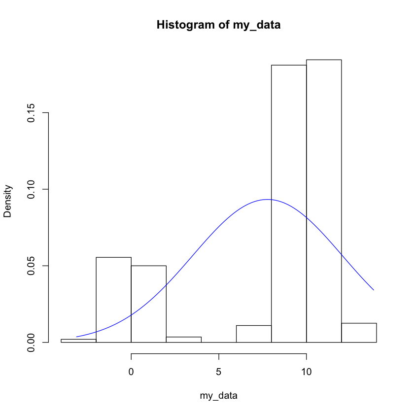

```r
hist(my_data, freq = FALSE)
best_normal <- function(x) return(dnorm(x, best_para[[1]], best_para[[2]]))
curve(best_normal, min(my_data), max(my_data), col="blue", add=TRUE)
```

### Problem 5: Generalizing functions

Here we'll relax the assumption that $k=2$.

- What happens when we pass a vector for the mean and sd, e.g. `rnorm(2, c(0, 10), c(0.1, 3))`?
  - What happens if you change `n=6`?
- Recall that we can subset the same index multiple times, e.g. `c(-1, -2, -3)[c(1, 1, 3)]`, use this fact and the above result to write rmixguass(). This function should avoid any for-loop or if/else logic.
  - Don't forget to update the input validation function as well!
- Check your function works by running

  ```
  dat <- rmixgauss(1000,
                   c(0.3, 0.1, 0.6),
                   c(-10, 0, 10),
                   c(1, 1, 3))
  hist(dat)
  ```

```r
# It generates one sample for each configuration
rnorm(2, c(0, 10), c(0.1, 3))
```

1. 0.0328483845386218

2. 7.18467721760229

```r
# The mean/sd are recycled
rnorm(6, c(0, 10), c(0.1, 3))
```

1. -0.144882549588763

2. 8.89925355268606

3. 0.0456027075393168

4. 8.72692674197926

5. 0.179109123275044

6. 6.04080288243945

```r
rmixgauss <- function(n, mix_probs, mus, sds) {
    check_rmixgauss_input(n, mix_probs, mus, sds)
    k <- length(mix_probs)
    rolls <- sample(k, n, replace=TRUE, prob = mix_probs)
    return(rnorm(n, mus[rolls], sds[rolls]))
}
```

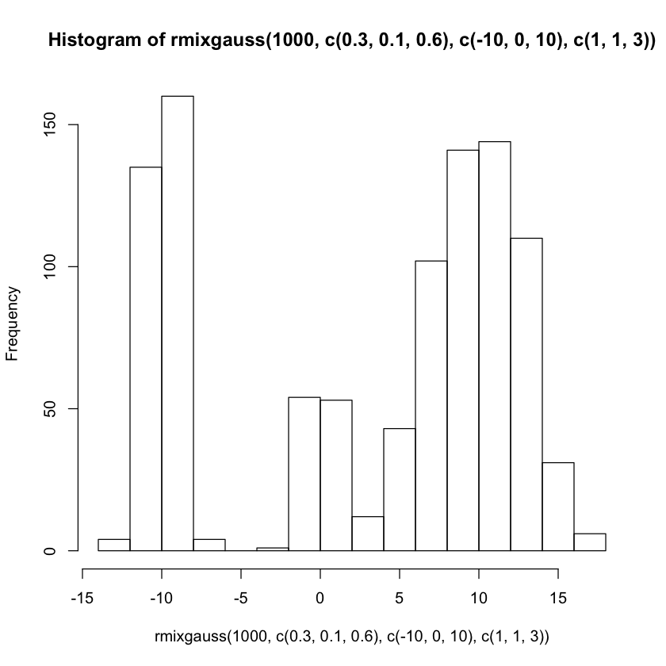

```r
hist(rmixgauss(1000, c(0.3, 0.1, 0.6), c(-10, 0, 10), c(1, 1, 3)))
```